# Twitter

2024-08-21

# Twitter Sentiment Analysis Data-set

| ID | Topic | Sentiment | Text |
| --- | --- | --- | --- |
| 2401 | Borderlands | Positive | im getting on borderlands and i will murder you all , |
| 2401 | Borderlands | Positive | I am coming to the borders and I will kill you all, |
| 2401 | Borderlands | Positive | im getting on borderlands and i will kill you all, |
| 2401 | Borderlands | Positive | im coming on borderlands and i will murder you all, |
| 2401 | Borderlands | Positive | im getting on borderlands 2 and i will murder you me all, |
| 2401 | Borderlands | Positive | im getting into borderlands and i can murder you all, |
| 2402 | Borderlands | Positive | So I spent a few hours making something for fun. . . If you don't know I am a HUGE @Borderlands fan and Maya is one of my favorite characters. So I decided to make myself a wallpaper for my PC. . Here… |
| 2402 | Borderlands | Positive | So I spent a couple of hours doing something for fun... If you don't know that I'm a huge @ Borderlands fan and Maya is one of my favorite characters, I decided to make a wallpaper for my PC.. Here's … |
| 2402 | Borderlands | Positive | So I spent a few hours doing something for fun... If you don't know I'm a HUGE @ Borderlands fan and Maya is one of my favorite characters. |
| 2402 | Borderlands | Positive | So I spent a few hours making something for fun. . . If you don't know I am a HUGE RhandlerR fan and Maya is one of my favorite characters. So I decided to make myself a wallpaper for my PC. . Here is… |

[output cut: 9990 more lines]

# Dimension of the data-set

```
[1] 74682     4
```

# Variables in the data-set

```
[1] "ID"        "Topic"     "Sentiment" "Text"
```

# Description of the variables in the dataset

```
'data.frame':   74682 obs. of  4 variables:
 $ ID       : int  2401 2401 2401 2401 2401 2401 2402 2402 2402 2402 ...
 $ Topic    : chr  "Borderlands" "Borderlands" "Borderlands" "Borderlands" ...
 $ Sentiment: chr  "Positive" "Positive" "Positive" "Positive" ...
 $ Text     : chr  "im getting on borderlands and i will murder you all ," "I am coming to the borders and I will kill you all," "im getting on borderlands and i will kill you all," "im coming on borderlands and i will murder you all," ...
```

# Summary of the data-set

```
       ID           Topic            Sentiment             Text
 Min.   :    1   Length:74682       Length:74682       Length:74682
 1st Qu.: 3195   Class :character   Class :character   Class :character
 Median : 6422   Mode  :character   Mode  :character   Mode  :character
 Mean   : 6433
 3rd Qu.: 9601
 Max.   :13200
```

# Checking for the missing values

```
[1] 0
```

# Column diagram for differnt topics vs count

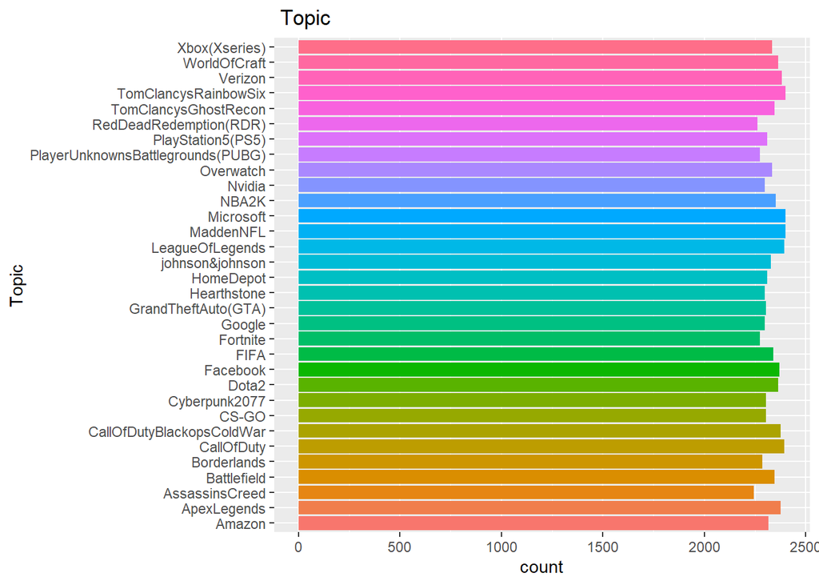

# Donut chart for Sentiment (Positive,Neutral,Negative,Irrelevant)

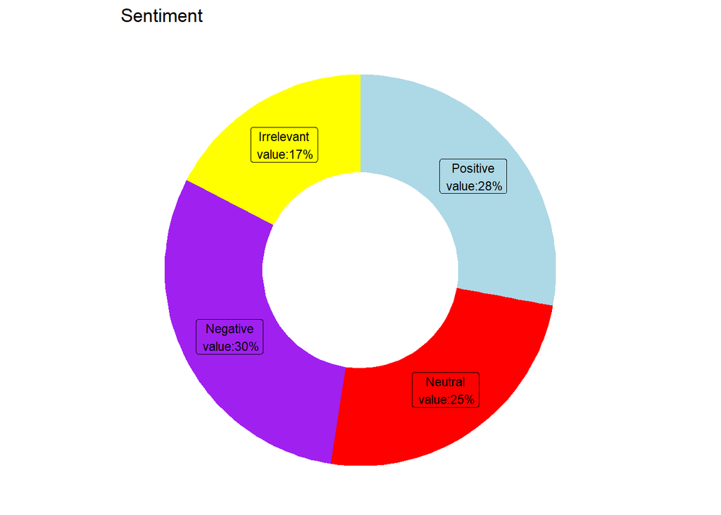

## **Bar chart for different levels of sentiment (Positive, Neutral, Negative, Irrelevant) vs. different topics**

[figure not shown]

### **We list the Twitter topics in decreasing order of their trending popularity.**

```
                        MaddenNFL                         Microsoft
                             2400                              2400
             TomClancysRainbowSix                        CallOfDuty
                             2400                              2394
                  LeagueOfLegends                           Verizon
                             2394                              2382
                      ApexLegends         CallOfDutyBlackopsColdWar
                             2376                              2376
                         Facebook                             Dota2
                             2370                              2364
                     WorldOfCraft                             NBA2K
                             2364                              2352
                      Battlefield              TomClancysGhostRecon
                             2346                              2346
                             FIFA                         Overwatch
                             2340                              2334
                    Xbox(Xseries)                   johnson&johnson
                             2334                              2328
                           Amazon                         HomeDepot
                             2316                              2310
                PlayStation5(PS5)                             CS-GO
                             2310                              2304
                    Cyberpunk2077               GrandTheftAuto(GTA)
                             2304                              2304
                           Google                       Hearthstone
                             2298                              2298
                           Nvidia                       Borderlands
                             2298                              2286
                         Fortnite PlayerUnknownsBattlegrounds(PUBG)
                             2274                              2274
           RedDeadRedemption(RDR)                    AssassinsCreed
                             2262                              2244
```

## **Sentiment Distribution for ‘Google’,‘Facebook’,‘Microsoft’ in Twitter**

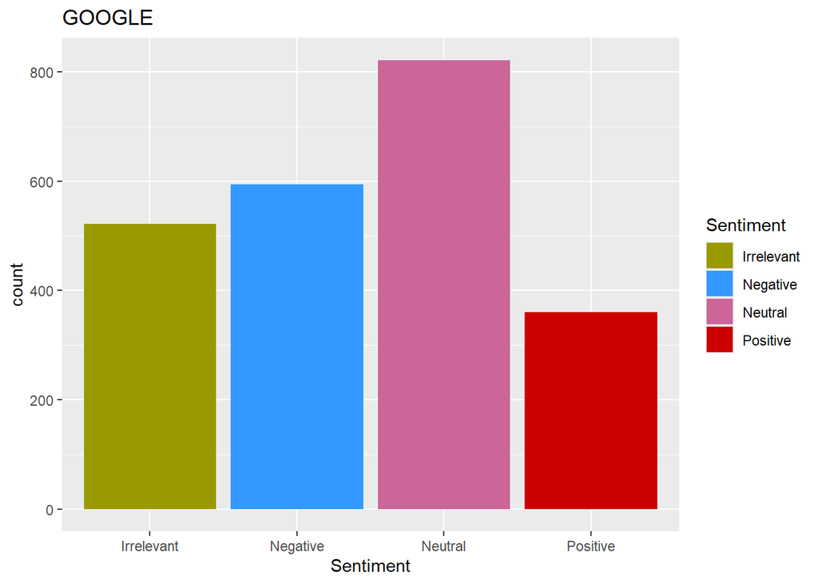

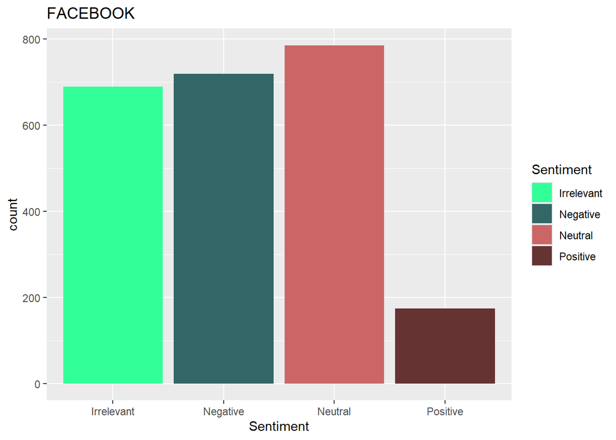

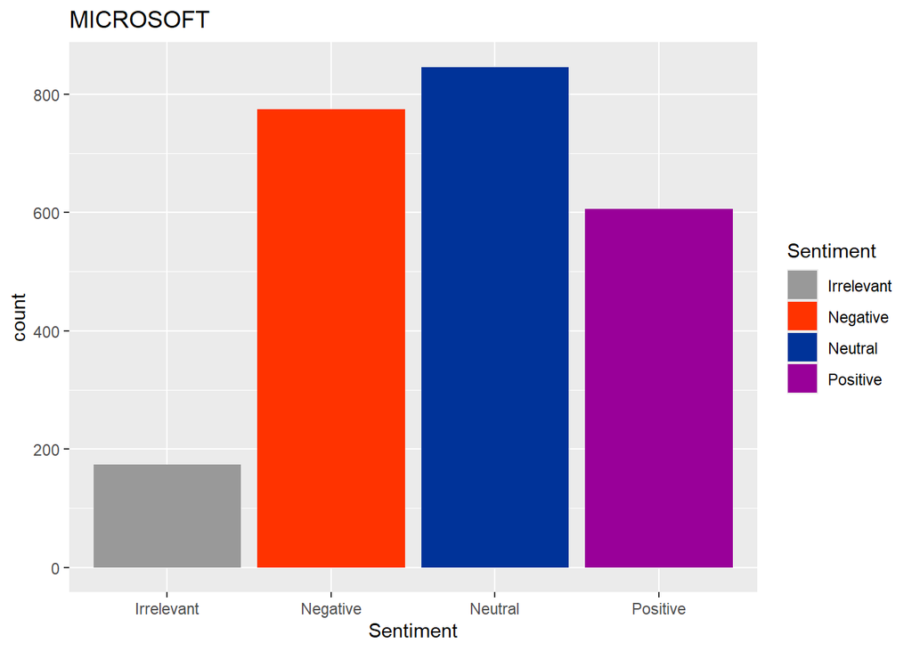

# Histogram of Text Length in Tweets

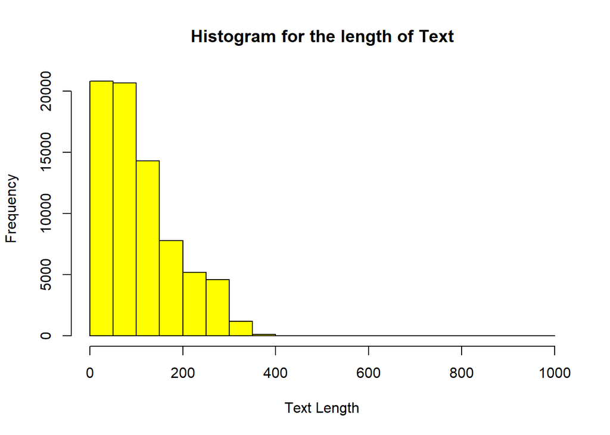

This histogram visualizes the distribution of tweet lengths based on the number of characters.

The distribution is right-skewed, with the majority of tweets having shorter text lengths.

The highest frequency of tweets falls within the 0 to 100 character range, with over 20,000 tweets in this interval. This indicates that most tweets are concise.

As text length increases, the frequency of tweets decreases sharply. Very few tweets exceed 300 characters, and tweets with lengths approaching the maximum of 1,000 characters are extremely rare.

### **This heatmap visualizes the relationship between sentiment (Positive, Neutral, Negative, Irrelevant) and various topics discussed on Twitter. Each cell in the heatmap represents the intensity or frequency of a particular sentiment associated with a specific topic, allowing for a quick identification of patterns and trends across different topics.**

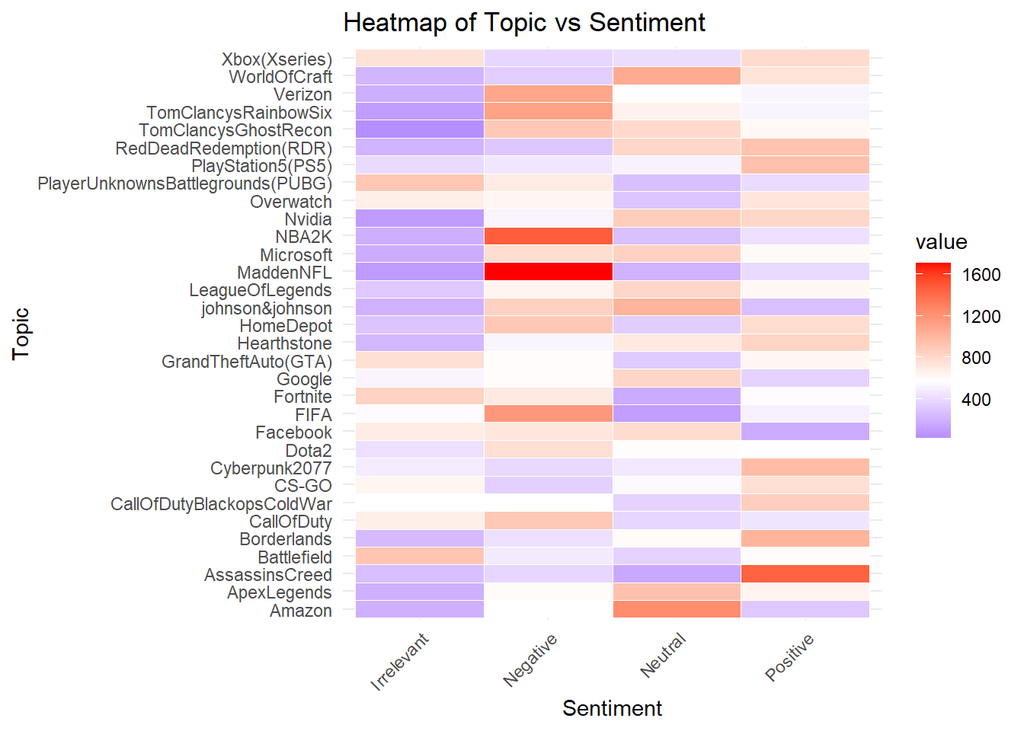

# Word Cloud

*In a word cloud, the size of each word indicates its frequency or importance—the larger the word, the more frequently it appears in the text.*

[interactive chart not shown]

Dominant Words: The largest words like “game,” “just,” “like,” “will,” and “good” are the most frequently mentioned in the dataset. This suggests that the tweets may be heavily focused on gaming-related discussions.

Sentiment and Topics: Words like “good,” “love,” and “great” suggest positive sentiment, while words like “fix,” “shit,” and “fucking” might indicate negative sentiment or frustration. The word “game” is central, which could imply that the primary topic of discussion is gaming.

Trends: The variety of words related to gaming, companies (e.g., “Verizon,” “Google,” “Amazon”), and social media engagement (e.g., “Facebook,” “Twitter”) indicate the topics that are trending or commonly discussed in the dataset.